# Climate vs Productivity Analysis - BrazilAgriAnalysis

James D.A. Millington

May 2019

```r
rm(list=ls())
library(tidyverse)
library(readxl)


label_long <- function(data) {

  data <- data %>%
    mutate(StateNM = if_else(State == 17, "TO",
       if_else(State == 29, "BA",
       if_else(State == 31, "MG",
       if_else(State == 35, "SP",
       if_else(State == 41, "PR",
       if_else(State == 42, "SC",
       if_else(State == 43, "RS",
       if_else(State == 50, "MS",
       if_else(State == 51, "MT",
       if_else(State == 52, "GO", NULL
       ))))))))))
     ) %>%

    #regions as discussed with Ramon 2019-05-07
    mutate(RegionNM = if_else(State == 17, "N",
       if_else(State == 29, "N",
       if_else(State == 31, "E",
       if_else(State == 35, "E",
       if_else(State == 41, "S",
       if_else(State == 42, "S",
       if_else(State == 43, "S",
       if_else(State == 50, "W",
       if_else(State == 51, "W",
       if_else(State == 52, "W", NULL
       ))))))))))
     ) %>%
  drop_na()

  return(data)

}
```

```r
##Load Production Data
soy <- readr::read_csv("ProductionData/soybean_Crop.csv",col_types=cols(.default=col_integer()), na="NA")
maize1 <- readr::read_csv("ProductionData/maize_first.csv",col_types=cols(.default=col_integer()), na="NA")
maize2 <- readr::read_csv("ProductionData/maize_second.csv",col_types=cols(.default=col_integer()), na="NA")

#go long
soy_long <- soy %>%
  gather(key = year, value = soy, -CODE)

maize1_long <- maize1 %>%
  gather(key = year, value = maize1, -CODE)

maize2_long <- maize2 %>%
  gather(key = year, value = maize2, -CODE)


##Load Climate data
CLmeans <- readr::read_csv("ClimateData/class-A-SH/ClimLim_MuniMeans.csv")
ACmeans <- readr::read_csv("ClimateData/class-A-SH/AgriCap_MuniMeans.csv")
DEFcmeans <- readr::read_csv("ClimateData/class-A-SH/countDEFmonths_MuniMeans.csv")
DEFmmeans <- readr::read_csv("ClimateData/class-A-SH/meanAnnualDEF_MuniMeans.csv")
DImeans <- readr::read_csv("ClimateData/class-A-SH/MeanAnnualDI_MuniMeans.csv")

#clean, go long
CLmeans_long <- CLmeans %>%
  dplyr::select(-NM_MUNICIP, -CD_GEOCMUn, -NM_ESTADO, -NM_REGIAO, -CD_GEOCUF) %>%
  gather(key = year, value = meanCL, -State, -CD_GEOCMU)

ACmeans_long <- ACmeans %>%
  dplyr::select(-NM_MUNICIP, -CD_GEOCMUn, -NM_ESTADO, -NM_REGIAO, -CD_GEOCUF) %>%
  gather(key = year, value = meanAC, -State, -CD_GEOCMU)

DEFcmeans_long <- DEFcmeans %>%
  dplyr::select(-NM_MUNICIP, -CD_GEOCMUn, -NM_ESTADO, -NM_REGIAO, -CD_GEOCUF) %>%
  gather(key = year, value = meanDEFc, -State, -CD_GEOCMU)

DEFmmeans_long <- DEFmmeans %>%
  dplyr::select(-NM_MUNICIP, -CD_GEOCMUn, -NM_ESTADO, -NM_REGIAO, -CD_GEOCUF) %>%
  gather(key = year, value = meanDEFm, -State, -CD_GEOCMU)

DImeans_long <- DImeans %>%
  dplyr::select(-NM_MUNICIP, -CD_GEOCMUn, -NM_ESTADO, -NM_REGIAO, -CD_GEOCUF) %>%
  gather(key = year, value = meanDI, -State, -CD_GEOCMU)


#join, add labels, go long
soyCLmeans_l <- label_long(left_join(CLmeans_long, soy_long, by = c("CD_GEOCMU" = "CODE", "year" = "year")))

soyACmeans_l <- label_long(left_join(ACmeans_long, soy_long, by = c("CD_GEOCMU" = "CODE", "year" = "year")))

soyDEFcmeans_l <- label_long(left_join(DEFcmeans_long, soy_long, by = c("CD_GEOCMU" = "CODE", "year" = "year")))

soyDEFmmeans_l <- label_long(left_join(DEFmmeans_long, soy_long, by = c("CD_GEOCMU" = "CODE", "year" = "year")))

soyDImeans_l <- label_long(left_join(DImeans_long, soy_long, by = c("CD_GEOCMU" = "CODE", "year" = "year")))

maize1CLmeans_l <- label_long(left_join(CLmeans_long, maize1_long, by = c("CD_GEOCMU" = "CODE", "year" = "year")))

maize1ACmeans_l <- label_long(left_join(ACmeans_long, maize1_long, by = c("CD_GEOCMU" = "CODE", "year" = "year")))

maize1DEFcmeans_l <- label_long(left_join(DEFcmeans_long, maize1_long, by = c("CD_GEOCMU" = "CODE", "year" = "year")))

maize1DEFmmeans_l <- label_long(left_join(DEFmmeans_long, maize1_long, by = c("CD_GEOCMU" = "CODE", "year" = "year")))

maize1DImeans_l <- label_long(left_join(DImeans_long, maize1_long, by = c("CD_GEOCMU" = "CODE", "year" = "year")))

maize2CLmeans_l <- label_long(left_join(CLmeans_long, maize2_long, by = c("CD_GEOCMU" = "CODE", "year" = "year")))

maize2ACmeans_l <- label_long(left_join(ACmeans_long, maize2_long, by = c("CD_GEOCMU" = "CODE", "year" = "year")))

maize2DEFcmeans_l <- label_long(left_join(DEFcmeans_long, maize2_long, by = c("CD_GEOCMU" = "CODE", "year" = "year")))

maize2DEFmmeans_l <- label_long(left_join(DEFmmeans_long, maize2_long, by = c("CD_GEOCMU" = "CODE", "year" = "year")))

maize2DImeans_l <- label_long(left_join(DImeans_long, maize2_long, by = c("CD_GEOCMU" = "CODE", "year" = "year")))
```

# Soy

## Climate Limitation

```r
muni_sum <- soyCLmeans_l %>%
  group_by(year, StateNM, RegionNM) %>%
  summarize(meanSoy = mean(soy),
            sdSoy   = sd(soy),
            meanCL = mean(meanCL),
            sdCL = sd(meanCL) ) %>%
  ungroup()

state_sum <- muni_sum %>%
  group_by(StateNM) %>%
  summarise(meanSoyPeriod = mean(meanSoy),
    meanCLPeriod = mean(meanCL)) %>%
  ungroup()

muni_states <- left_join(muni_sum, state_sum)

muni_states <- muni_states %>%
  group_by(year, StateNM, RegionNM) %>%
  summarize(diffcSoyPeriod = meanSoy - meanSoyPeriod,
    diffcCLPeriod= meanCL - meanCLPeriod ) %>%
  ungroup()

muni_sum <- left_join(muni_sum, muni_states, b = c("year"="year","StateNM"="StateNM","RegionNM"="RegionNM"))
```

### Time Series

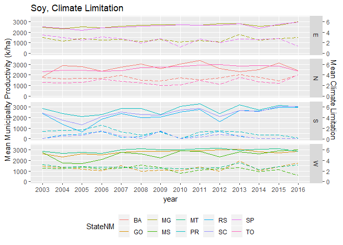

```r
muni_sum %>%
  ggplot(aes(x=year, group=StateNM)) +
  geom_line(aes(y=meanSoy, colour=StateNM)) +
  geom_line(aes(y=meanCL*500, colour=StateNM), linetype="longdash") +
  scale_y_continuous(sec.axis = sec_axis(~./500, name = "Mean Climate Limitation")) +
  facet_grid(RegionNM~.) +
  ggtitle("Soy, Climate Limitation") +
  ylab("Mean Municipality Productivity (k/ha)") +
  theme(legend.position = "bottom")
```

Dotted line is climate variable

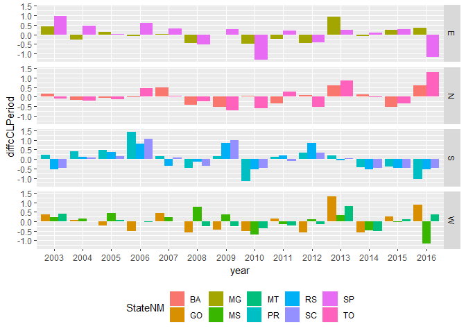

```r
muni_sum %>%
  ggplot(aes(x=year, y=diffcCLPeriod, group=StateNM)) +
  geom_bar(stat="identity", position="dodge", aes(fill=StateNM)) +
  facet_grid(RegionNM~.) +
  theme(legend.position = "bottom")
```

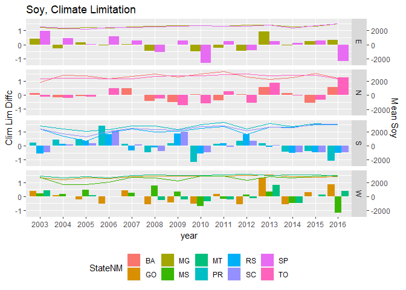

```r
muni_sum %>%
  ggplot(aes(x=year, y=diffcCLPeriod, group=StateNM)) +
  geom_bar(stat="identity", position="dodge", aes(fill=StateNM)) +
  geom_line(aes(y=meanSoy/2000, colour=StateNM)) +
  scale_y_continuous(sec.axis = sec_axis(~.*2000, name = "Mean Soy")) +
  facet_grid(RegionNM~.) +
  ggtitle("Soy, Climate Limitation") +
  ylab("Clim Lim Diffc") +
  theme(legend.position = "bottom")
```

Differences are from the mean value for the period 2003-2016

### Scatter (points are years)

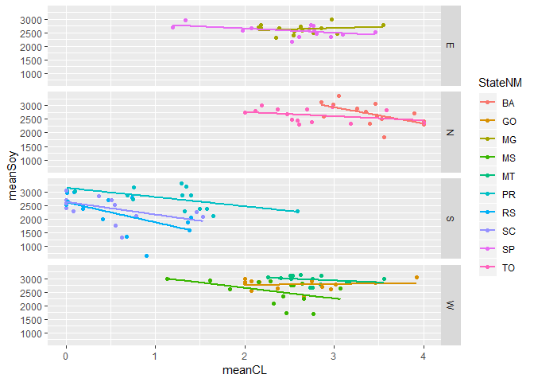

```r
muni_sum %>%
  ggplot(aes(x=meanCL, y=meanSoy)) +
  geom_point(aes(colour=StateNM)) +
  geom_smooth(aes(group=StateNM, colour = StateNM),method=lm, se=F) +
  facet_grid(RegionNM~.)
```

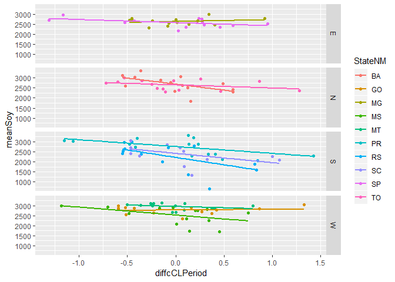

```r
muni_sum %>%
  ggplot(aes(x=diffcCLPeriod, y=meanSoy)) +
  geom_point(aes(colour=StateNM)) +
  geom_smooth(aes(group=StateNM, colour = StateNM),method=lm, se=F) +
  facet_grid(RegionNM~.)
```

## Agricultural Capital

```r
muni_sum <- soyACmeans_l %>%
  group_by(year, StateNM, RegionNM) %>%
  summarize(meanSoy = mean(soy),
            sdSoy   = sd(soy),
            meanAC = mean(meanAC),
            sdAC = sd(meanAC)) %>%
  ungroup()

state_sum <- muni_sum %>%
  group_by(StateNM) %>%
  summarise(meanSoyPeriod = mean(meanSoy),
    meanACPeriod = mean(meanAC)) %>%
  ungroup()

muni_states <- left_join(muni_sum, state_sum)

muni_states <- muni_states %>%
  group_by(year, StateNM, RegionNM) %>%
  summarize(diffcSoyPeriod = meanSoy - meanSoyPeriod,
    diffcACPeriod= meanAC - meanACPeriod ) %>%
  ungroup()

muni_sum <- left_join(muni_sum, muni_states, b = c("year"="year","StateNM"="StateNM","RegionNM"="RegionNM"))
```

### Time Series

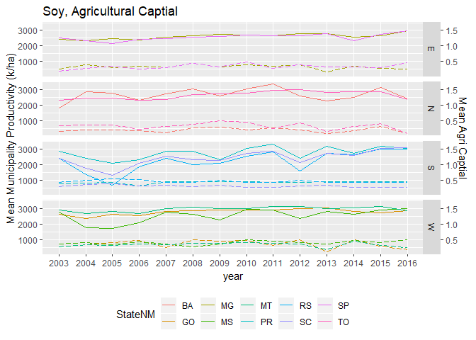

```r
muni_sum %>%
  ggplot(aes(x=year, group=StateNM)) +
  geom_line(aes(y=meanSoy, colour=StateNM)) +
  geom_line(aes(y=meanAC*2000, colour=StateNM), linetype="longdash") +
  scale_y_continuous(sec.axis = sec_axis(~./2000, name = "Mean Agri Captial")) +
  facet_grid(RegionNM~.) +
  ggtitle("Soy, Agricultural Captial") +
  ylab("Mean Municipality Productivity (k/ha)") +
  theme(legend.position = "bottom")
```

Dotted line is climate variable

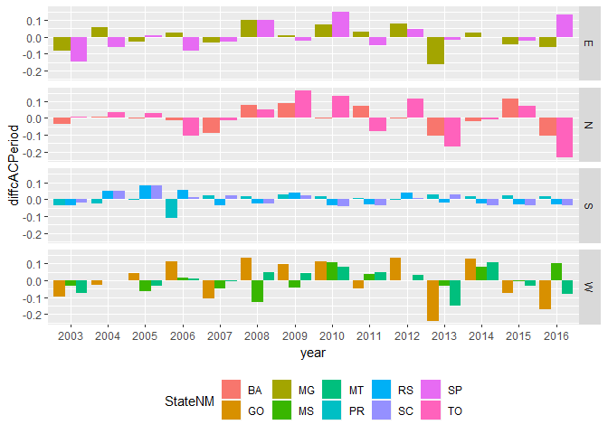

```r
muni_sum %>%
  ggplot(aes(x=year, y=diffcACPeriod, group=StateNM)) +
  geom_bar(stat="identity", position="dodge", aes(fill=StateNM)) +
  facet_grid(RegionNM~.) +
  theme(legend.position = "bottom")
```

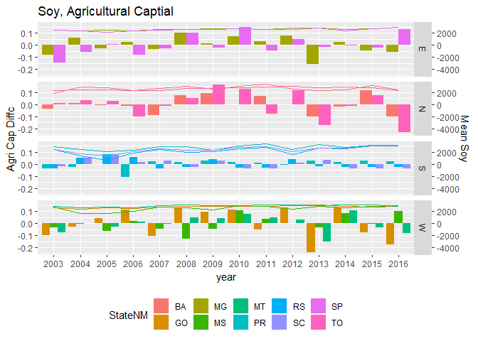

```r
muni_sum %>%
  ggplot(aes(x=year, y=diffcACPeriod, group=StateNM)) +
  geom_bar(stat="identity", position="dodge", aes(fill=StateNM)) +
  geom_line(aes(y=meanSoy/20000, colour=StateNM)) +
  scale_y_continuous(sec.axis = sec_axis(~.*20000, name = "Mean Soy")) +
  facet_grid(RegionNM~.) +
  ggtitle("Soy, Agricultural Captial") +
  ylab("Agri Cap Diffc") +
  theme(legend.position = "bottom")
```

Differences are from the mean value for the period 2003-2016

### Scatter (points are years)

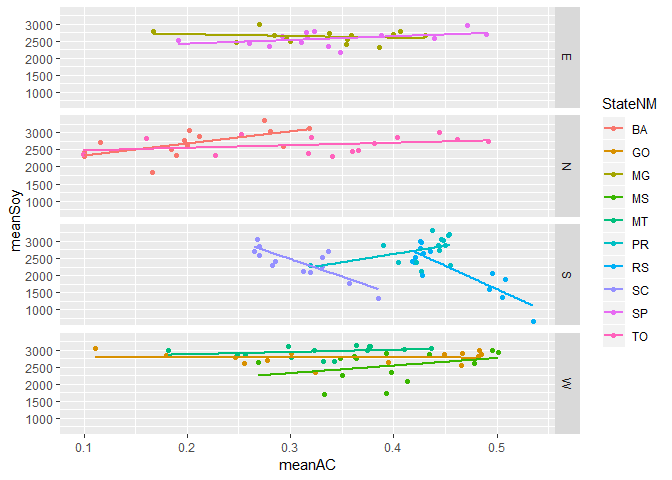

```r
muni_sum %>%
  ggplot(aes(x=meanAC, y=meanSoy)) +
  geom_point(aes(colour=StateNM)) +
  geom_smooth(aes(group=StateNM, colour = StateNM),method=lm, se=F) +
  facet_grid(RegionNM~.)
```

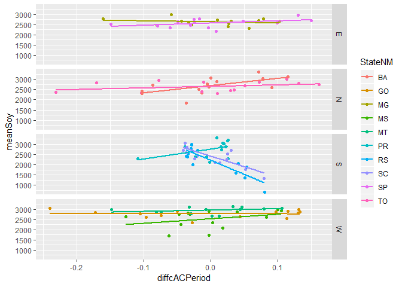

```r
muni_sum %>%
  ggplot(aes(x=diffcACPeriod, y=meanSoy)) +
  geom_point(aes(colour=StateNM)) +
  geom_smooth(aes(group=StateNM, colour = StateNM),method=lm, se=F) +
  facet_grid(RegionNM~.)
```

## DEF months count

```r
muni_sum <- soyDEFcmeans_l %>%
  group_by(year, StateNM, RegionNM) %>%
  summarize(meanSoy = mean(soy),
            sdSoy   = sd(soy),
            meanDEFc = mean(meanDEFc),
            sdDEFc = sd(meanDEFc) ) %>%
  ungroup()

state_sum <- muni_sum %>%
  group_by(StateNM) %>%
  summarise(meanSoyPeriod = mean(meanSoy),
    meanDEFcPeriod = mean(meanDEFc)) %>%
  ungroup()

muni_states <- left_join(muni_sum, state_sum)

muni_states <- muni_states %>%
  group_by(year, StateNM, RegionNM) %>%
  summarize(diffcSoyPeriod = meanSoy - meanSoyPeriod,
    diffcDEFcPeriod= meanDEFc - meanDEFcPeriod) %>%
  ungroup()

muni_sum <- left_join(muni_sum, muni_states, b = c("year"="year","StateNM"="StateNM","RegionNM"="RegionNM"))
```

### Time Series

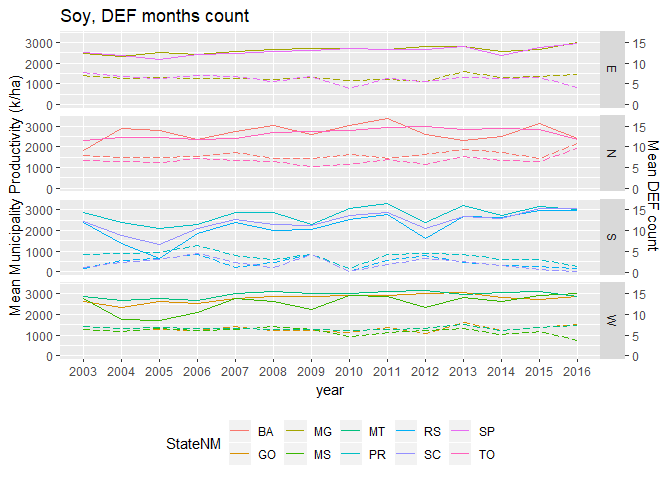

```r
muni_sum %>%
  ggplot(aes(x=year, group=StateNM)) +
  geom_line(aes(y=meanSoy, colour=StateNM)) +
  geom_line(aes(y=meanDEFc*200, colour=StateNM), linetype="longdash") +
  scale_y_continuous(sec.axis = sec_axis(~./200, name = "Mean DEF count")) +
  facet_grid(RegionNM~.) +
  ggtitle("Soy, DEF months count") +
  ylab("Mean Municipality Productivity (k/ha)") +
  theme(legend.position = "bottom")
```

Dotted line is climate variable

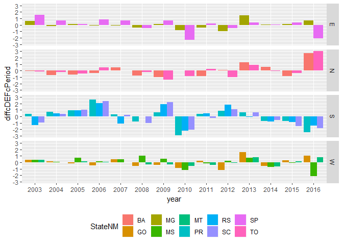

```r
muni_sum %>%
  ggplot(aes(x=year, y=diffcDEFcPeriod, group=StateNM)) +
  geom_bar(stat="identity", position="dodge", aes(fill=StateNM)) +
  facet_grid(RegionNM~.)  +
  theme(legend.position = "bottom")
```

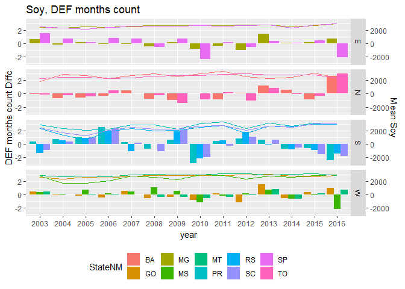

```r
muni_sum %>%
  ggplot(aes(x=year, y=diffcDEFcPeriod, group=StateNM)) +
  geom_bar(stat="identity", position="dodge", aes(fill=StateNM)) +
  geom_line(aes(y=meanSoy/1000, colour=StateNM)) +
  scale_y_continuous(sec.axis = sec_axis(~.*1000, name = "Mean Soy")) +
  facet_grid(RegionNM~.) +
  ggtitle("Soy, DEF months count") +
  ylab("DEF months count Diffc") +
  theme(legend.position = "bottom")
```

Differences are from the mean value for the period 2003-2016

### Scatter (points are years)

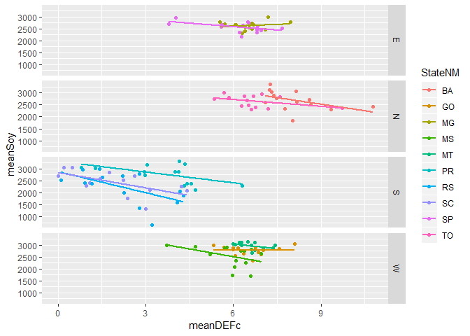

```r
muni_sum %>%
  ggplot(aes(x=meanDEFc, y=meanSoy)) +
  geom_point(aes(colour=StateNM)) +
  geom_smooth(aes(group=StateNM, colour = StateNM),method=lm, se=F) +
  facet_grid(RegionNM~.)
```

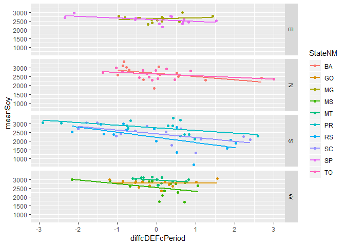

```r
muni_sum %>%
  ggplot(aes(x=diffcDEFcPeriod, y=meanSoy)) +
  geom_point(aes(colour=StateNM)) +
  geom_smooth(aes(group=StateNM, colour = StateNM),method=lm, se=F) +
  facet_grid(RegionNM~.)
```

## DEF months mean

```r
muni_sum <- soyDEFmmeans_l %>%
  group_by(year, StateNM, RegionNM) %>%
  summarize(meanSoy = mean(soy),
            sdSoy   = sd(soy),
            meanDEFm = mean(meanDEFm),
            sdDEFm = sd(meanDEFm) ) %>%
  ungroup()

state_sum <- muni_sum %>%
  group_by(StateNM) %>%
  summarise(meanSoyPeriod = mean(meanSoy),
    meanDEFmPeriod = mean(meanDEFm)) %>%
  ungroup()

muni_states <- left_join(muni_sum, state_sum)

muni_states <- muni_states %>%
  group_by(year, StateNM, RegionNM) %>%
  summarize(diffcSoyPeriod = meanSoy - meanSoyPeriod,
    diffcDEFmPeriod= meanDEFm - meanDEFmPeriod) %>%
  ungroup()

muni_sum <- left_join(muni_sum, muni_states, b = c("year"="year","StateNM"="StateNM","RegionNM"="RegionNM"))
```

### Time Series

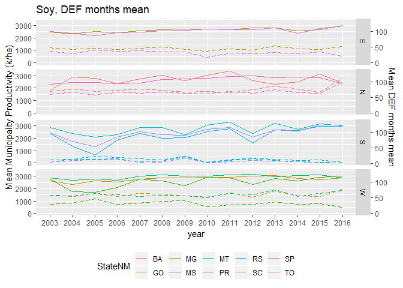

```r
muni_sum %>%
  ggplot(aes(x=year, group=StateNM)) +
  geom_line(aes(y=meanSoy, colour=StateNM)) +
  geom_line(aes(y=meanDEFm*25, colour=StateNM), linetype="longdash") +
  scale_y_continuous(sec.axis = sec_axis(~./25, name = "Mean DEF months mean")) +
  facet_grid(RegionNM~.) +
  ggtitle("Soy, DEF months mean") +
  ylab("Mean Municipality Productivity (k/ha)") +
  theme(legend.position = "bottom")
```

Dotted line is climate variable

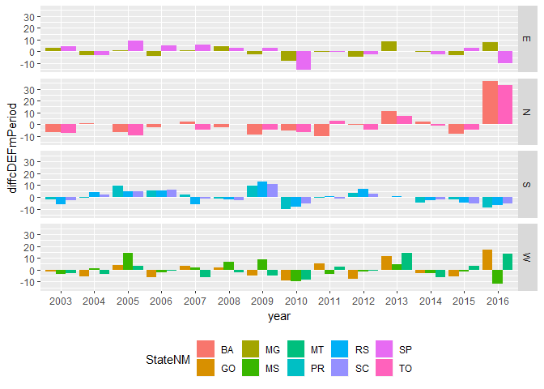

```r
muni_sum %>%
  ggplot(aes(x=year, y=diffcDEFmPeriod, group=StateNM)) +
  geom_bar(stat="identity", position="dodge", aes(fill=StateNM)) +
  facet_grid(RegionNM~.)  +
  theme(legend.position = "bottom")
```

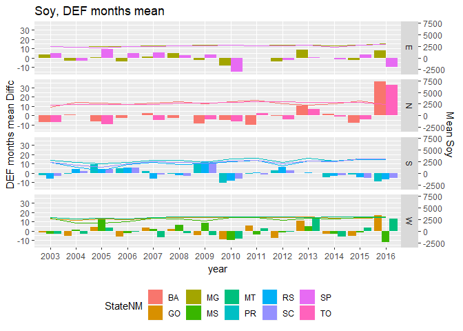

```r
muni_sum %>%
  ggplot(aes(x=year, y=diffcDEFmPeriod, group=StateNM)) +
  geom_bar(stat="identity", position="dodge", aes(fill=StateNM)) +
  geom_line(aes(y=meanSoy/200, colour=StateNM)) +
  scale_y_continuous(sec.axis = sec_axis(~.*200, name = "Mean Soy")) +
  facet_grid(RegionNM~.) +
  ggtitle("Soy, DEF months mean") +
  ylab("DEF months mean Diffc") +
  theme(legend.position = "bottom")
```

Differences are from the mean value for the period 2003-2016

### Scatter (points are years)

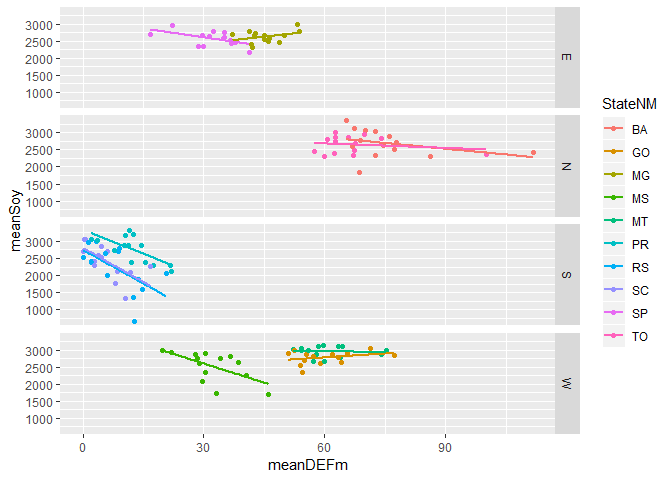

```r
muni_sum %>%
  ggplot(aes(x=meanDEFm, y=meanSoy)) +
  geom_point(aes(colour=StateNM)) +
  geom_smooth(aes(group=StateNM, colour = StateNM),method=lm, se=F) +
  facet_grid(RegionNM~.)
```

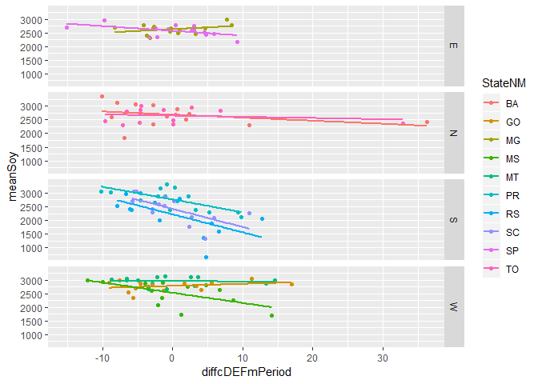

```r
muni_sum %>%
  ggplot(aes(x=diffcDEFmPeriod, y=meanSoy)) +
  geom_point(aes(colour=StateNM)) +
  geom_smooth(aes(group=StateNM, colour = StateNM),method=lm, se=F) +
  facet_grid(RegionNM~.)
```

## Dryness Index

```r
muni_sum <- soyDImeans_l %>%
  group_by(year, StateNM, RegionNM) %>%
  summarize(meanSoy = mean(soy),
            sdSoy   = sd(soy),
            meanDI = mean(meanDI),
            sdDI = sd(meanDI) ) %>%
  ungroup()

state_sum <- muni_sum %>%
  group_by(StateNM) %>%
  summarise(meanSoyPeriod = mean(meanSoy),
    meanDIPeriod = mean(meanDI)) %>%
  ungroup()

muni_states <- left_join(muni_sum, state_sum)

muni_states <- muni_states %>%
  group_by(year, StateNM, RegionNM) %>%
  summarize(
    diffcSoyPeriod = meanSoy - meanSoyPeriod,
    diffcDIPeriod= meanDI - meanDIPeriod) %>%
  ungroup()

muni_sum <- left_join(muni_sum, muni_states, b = c("year"="year","StateNM"="StateNM","RegionNM"="RegionNM"))
```

### Time Series

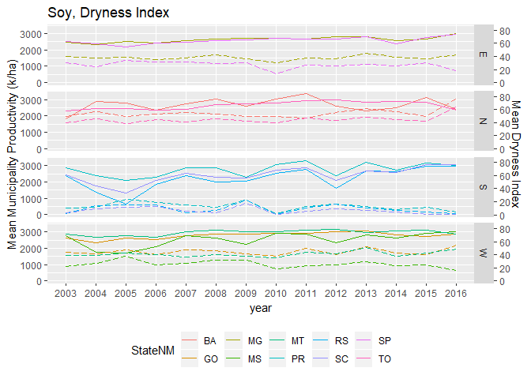

```r
muni_sum %>%
  ggplot(aes(x=year, group=StateNM)) +
  geom_line(aes(y=meanSoy, colour=StateNM)) +
  geom_line(aes(y=meanDI*40, colour=StateNM), linetype="longdash") +
  scale_y_continuous(sec.axis = sec_axis(~./40, name = "Mean Dryness Index")) +
  facet_grid(RegionNM~.) +
  ggtitle("Soy, Dryness Index") +
  ylab("Mean Municipality Productivity (k/ha)") +
  theme(legend.position = "bottom")
```

Dotted line is climate variable

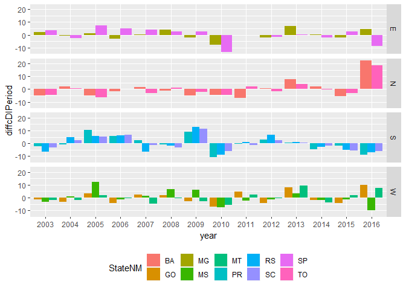

```r
muni_sum %>%
  ggplot(aes(x=year, y=diffcDIPeriod, group=StateNM)) +
  geom_bar(stat="identity", position="dodge", aes(fill=StateNM)) +
  facet_grid(RegionNM~.)  +
  theme(legend.position = "bottom")
```

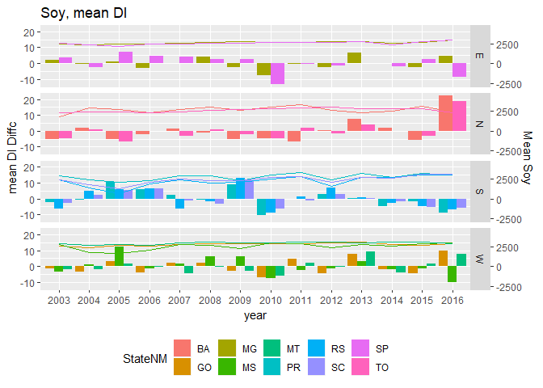

```r
muni_sum %>%
  ggplot(aes(x=year, y=diffcDIPeriod, group=StateNM)) +
  geom_bar(stat="identity", position="dodge", aes(fill=StateNM)) +
  geom_line(aes(y=meanSoy/200, colour=StateNM)) +
  scale_y_continuous(sec.axis = sec_axis(~.*200, name = "Mean Soy")) +
  facet_grid(RegionNM~.) +
  ggtitle("Soy, mean DI") +
  ylab("mean DI Diffc") +
  theme(legend.position = "bottom")
```

Differences are from the mean value for the period 2003-2016

### Scatter (points are years)

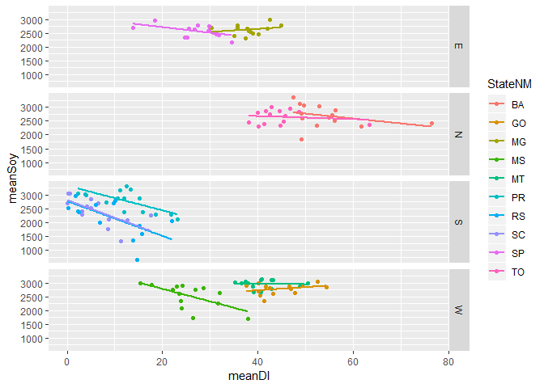

```r
muni_sum %>%
  ggplot(aes(x=meanDI, y=meanSoy)) +
  geom_point(aes(colour=StateNM)) +
  geom_smooth(aes(group=StateNM, colour = StateNM),method=lm, se=F) +
  facet_grid(RegionNM~.)
```

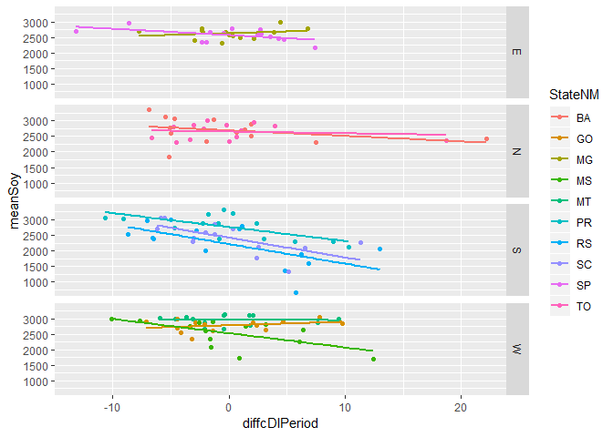

```r
muni_sum %>%
  ggplot(aes(x=diffcDIPeriod, y=meanSoy)) +
  geom_point(aes(colour=StateNM)) +
  geom_smooth(aes(group=StateNM, colour = StateNM),method=lm, se=F) +
  facet_grid(RegionNM~.)
```

# Maize1

## Climate Limitation

```r
muni_sum <- maize1CLmeans_l %>%
  group_by(year, StateNM, RegionNM) %>%
  summarize(meanmaize1 = mean(maize1),
            sdmaize1   = sd(maize1),
            meanCL = mean(meanCL),
            sdCL = sd(meanCL) ) %>%
  ungroup()

state_sum <- muni_sum %>%
  group_by(StateNM) %>%
  summarise(meanmaize1Period = mean(meanmaize1),
    meanCLPeriod = mean(meanCL)) %>%
  ungroup()

muni_states <- left_join(muni_sum, state_sum)

muni_states <- muni_states %>%
  group_by(year, StateNM, RegionNM) %>%
  summarize(diffcmaize1Period = meanmaize1 - meanmaize1Period,
    diffcCLPeriod= meanCL - meanCLPeriod ) %>%
  ungroup()

muni_sum <- left_join(muni_sum, muni_states, b = c("year"="year","StateNM"="StateNM","RegionNM"="RegionNM"))
```

### Time Series

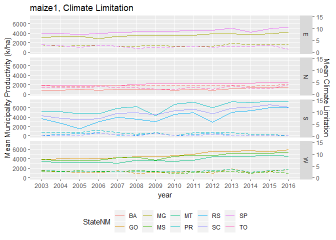

```r
muni_sum %>%
  ggplot(aes(x=year, group=StateNM)) +
  geom_line(aes(y=meanmaize1, colour=StateNM)) +
  geom_line(aes(y=meanCL*500, colour=StateNM), linetype="longdash") +
  scale_y_continuous(sec.axis = sec_axis(~./500, name = "Mean Climate Limitation")) +
  facet_grid(RegionNM~.) +
  ggtitle("maize1, Climate Limitation") +
  ylab("Mean Municipality Productivity (k/ha)") +
  theme(legend.position = "bottom")
```

Dotted line is climate variable

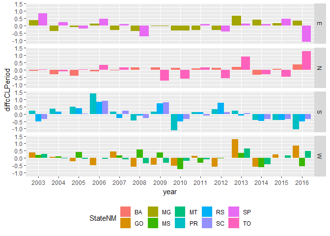

```r
muni_sum %>%
  ggplot(aes(x=year, y=diffcCLPeriod, group=StateNM)) +
  geom_bar(stat="identity", position="dodge", aes(fill=StateNM)) +
  facet_grid(RegionNM~.) +
  theme(legend.position = "bottom")
```

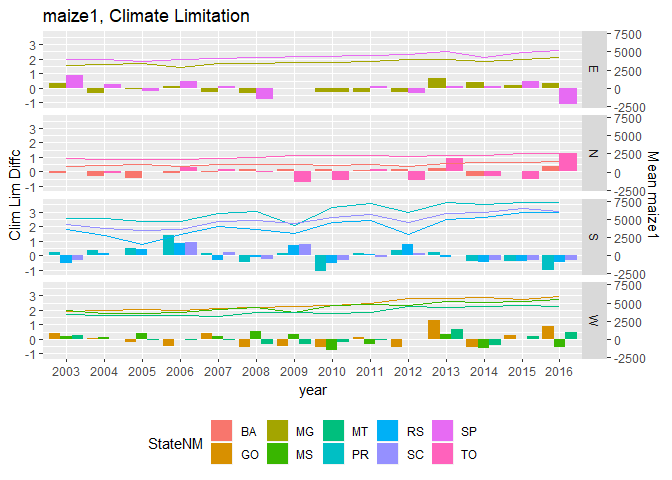

```r
muni_sum %>%
  ggplot(aes(x=year, y=diffcCLPeriod, group=StateNM)) +
  geom_bar(stat="identity", position="dodge", aes(fill=StateNM)) +
  geom_line(aes(y=meanmaize1/2000, colour=StateNM)) +
  scale_y_continuous(sec.axis = sec_axis(~.*2000, name = "Mean maize1")) +
  facet_grid(RegionNM~.) +
  ggtitle("maize1, Climate Limitation") +
  ylab("Clim Lim Diffc") +
  theme(legend.position = "bottom")
```

Differences are from the mean value for the period 2003-2016

### Scatter (points are years)

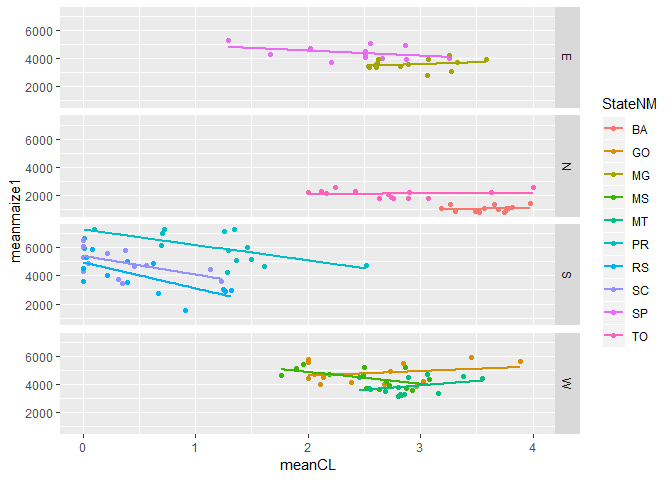

```r
muni_sum %>%
  ggplot(aes(x=meanCL, y=meanmaize1)) +
  geom_point(aes(colour=StateNM)) +
  geom_smooth(aes(group=StateNM, colour = StateNM),method=lm, se=F) +
  facet_grid(RegionNM~.)
```

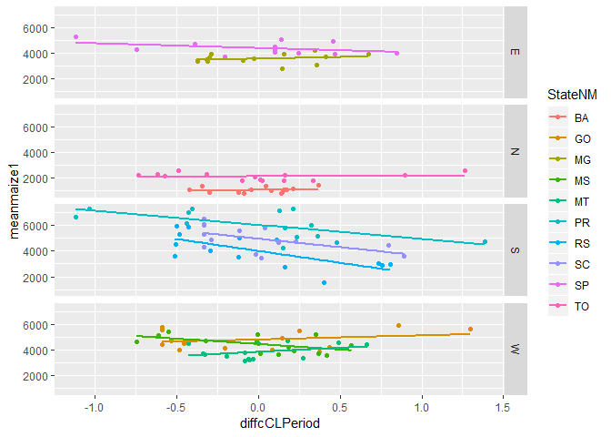

```r
muni_sum %>%
  ggplot(aes(x=diffcCLPeriod, y=meanmaize1)) +
  geom_point(aes(colour=StateNM)) +
  geom_smooth(aes(group=StateNM, colour = StateNM),method=lm, se=F) +
  facet_grid(RegionNM~.)
```